# Penalized Precision Matrix Estimation in grasps

## Preliminary

Consider the following setting:

- **Gaussian graphical model (GGM) assumption:**  
  The data *X*<sub>*n* × *p*</sub> consists of independent and identically distributed samples *X*<sub>1</sub>, …, *X*<sub>*n*</sub> ∼ *N*<sub>*p*</sub>(*μ*, *Σ*).
- **Disjoint group structure:**  
  The *p* variables can be partitioned into disjoint groups.
- **Goal:**  
  Estimate the precision matrix *Ω* = *Σ*<sup>−1</sup> = (*ω*<sub>*i**j*</sub>)<sub>*p* × *p*</sub>.

## Sparse-Group Estimator

- $S = n^{-1} \sum_{i=1}^n (X_i-\bar{X})(X_i-\bar{X})^\top$ is the empirical covariance matrix.
- *λ* ≥ 0 is the global regularization parameter controlling overall shrinkage.
- *α* ∈ [0, 1] is the mixing parameter controlling the balance between element-wise and block-wise penalties.
- *γ* is the additional parameter for non-convex penalties, controlling the degree of nonconvexity (or concavity) of the penalty function.
- 𝒫<sub>*λ*, *α*, *γ*</sub>(*Ω*) is a generic bi-level penalty template that combines element-wise and block-wise regularization, allowing convex or non-convex regularizers while preserving the intrinsic group structure among variables.
- 𝒫<sub>*λ*, *γ*</sub><sup>idv</sup>(*Ω*) is the element-wise individual penalty component.
- 𝒫<sub>*λ*, *γ*</sub><sup>grp</sup>(*Ω*) is the block-wise group penalty component.
- *P*<sub>*λ*, *γ*</sub>(⋅) is the penalty function.
- *Ω*<sub>*g**g*<sup>′</sup></sub> is the submatrix of *Ω* with the rows from group *g* and columns from group *g*<sup>′</sup>.
- The Frobenius norm ‖*Ω*‖<sub>*F*</sub> is defined as ‖*Ω*‖<sub>*F*</sub> = (∑<sub>*i*, *j*</sub>|*ω*<sub>*i**j*</sub>|<sup>2</sup>)<sup>1/2</sup> = [tr(*Ω*<sup>⊤</sup>*Ω*)]<sup>1/2</sup>.

**Note**:

- The parameter *γ* is only relevant for non-convex penalties. The Lasso penalty can be viewed as a special case in which *γ* is not required.

## Penalties

1. Lasso: Least absolute shrinkage and selection operator (Tibshirani 1996; Friedman et al. 2008)

*P*<sub>*λ*</sub>(*ω*<sub>*i**j*</sub>) = *λ*|*ω*<sub>*i**j*</sub>|.

2. Adaptive lasso (Zou 2006; Fan et al. 2009)

$$P_{\lambda,\gamma}(\omega_{ij}) = \lambda\frac{\vert\omega_{ij}\vert}{v_{ij}},$$
where *V* = (*v*<sub>*i**j*</sub>)<sub>*d* × *d*</sub> = (|*ω̃*<sub>*i**j*</sub>|<sup>*γ*</sup>)<sub>*d* × *d*</sub> is a matrix of adaptive weights, and *ω̃*<sub>*i**j*</sub> is the initial estimate obtained using `penalty = "lasso"`.

3. Atan: Arctangent type penalty (Wang and Zhu 2016)

$$P_{\lambda,\gamma}(\omega_{ij})
= \lambda(\gamma+\frac{2}{\pi})
\arctan\left(\frac{\vert\omega_{ij}\vert}{\gamma}\right),
\quad \gamma > 0.$$

4. Exp: Exponential type penalty (Wang et al. 2018)

$$P_{\lambda,\gamma}(\omega_{ij})
= \lambda\left[1-\exp\left(-\frac{\vert\omega_{ij}\vert}{\gamma}\right)\right],
\quad \gamma > 0.$$

5. Lq (Frank and Friedman 1993; Fu 1998; Fan and Li 2001)

*P*<sub>*λ*, *γ*</sub>(*ω*<sub>*i**j*</sub>) = *λ*|*ω*<sub>*i**j*</sub>|<sup>*γ*</sup>, 0 < *γ* < 1.

6. LSP: Log-sum penalty (Candès et al. 2008)

$$P_{\lambda,\gamma}(\omega_{ij})
= \lambda\log\left(1+\frac{\vert\omega_{ij}\vert}{\gamma}\right),
\quad \gamma > 0.$$

7. MCP: Minimax concave penalty (Zhang 2010)

$$P_{\lambda,\gamma}(\omega_{ij})
= \begin{cases}
\lambda\vert\omega_{ij}\vert - \dfrac{\omega_{ij}^2}{2\gamma},
& \text{if } \vert\omega_{ij}\vert \leq \gamma\lambda, \\
\dfrac{1}{2}\gamma\lambda^2,
& \text{if } \vert\omega_{ij}\vert > \gamma\lambda.
\end{cases}
\quad \gamma > 1.$$

8. SCAD: Smoothly clipped absolute deviation (Fan and Li 2001; Fan et al. 2009)

$$P_{\lambda,\gamma}(\omega_{ij})
= \begin{cases}
\lambda\vert\omega_{ij}\vert
& \text{if } \vert\omega_{ij}\vert \leq \lambda, \\
\dfrac{2\gamma\lambda\vert\omega_{ij}\vert-\omega_{ij}^2-\lambda^2}{2(\gamma-1)}
& \text{if } \lambda < \vert\omega_{ij}\vert < \gamma\lambda, \\
\dfrac{\lambda^2(\gamma+1)}{2}
& \text{if } \vert\omega_{ij}\vert \geq \gamma\lambda.
\end{cases}
\quad \gamma > 2.$$

**Note**:

- For Lasso, which is convex, the additional parameter *γ* is not required, and the penalty function *P*<sub>*λ*, *γ*</sub>(⋅) simplifies to *P*<sub>*λ*</sub>(⋅).

## Illustrative Visualization

Figure 1 illustrates a comparison of various penalty functions *P*(*ω*) evaluated over a range of *ω* values. The main panel (right) provides a wider view of the penalty functions’ behavior for larger |*ω*|, while the inset panel (left) magnifies the region near zero $[−1, 1]$.

```r
library(grasps) ## for penalty computation
library(ggplot2) ## for visualization

penalties <- c("atan", "exp", "lasso", "lq", "lsp", "mcp", "scad")

pen_df <- compute_penalty(seq(-4, 4, by = 0.01), penalties, lambda = 1)
plot(pen_df, xlim = c(-1, 1), ylim = c(0, 1), zoom.size = 1) +
  guides(color = guide_legend(nrow = 2, byrow = TRUE))
```

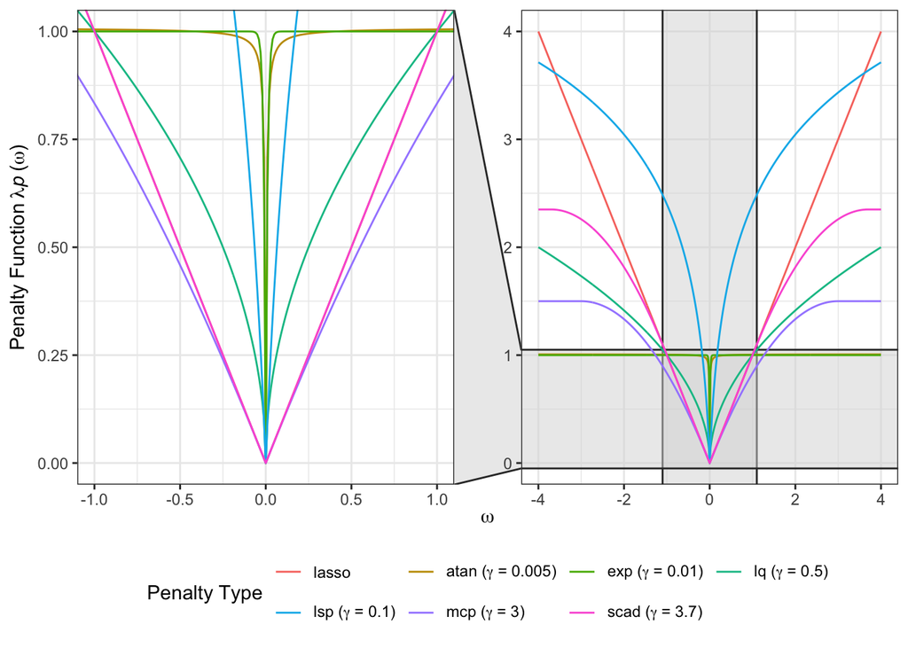

Figure 1: Illustrative penalty functions.

Figure 2 displays the derivative function *P*<sup>′</sup>(*ω*) associated with a range of penalty types. The Lasso exhibits a constant derivative, corresponding to uniform shrinkage. For MCP and SCAD, the derivatives are piecewise: initially equal to the Lasso derivative, then decreasing over an intermediate region, and eventually dropping to zero, indicating that large |*ω*| receive no shrinkage. Other non-convex penalties show smoothly diminishing derivatives as |*ω*| increases, reflecting their tendency to shrink small |*ω*| strongly while exerting little to no shrinkage on large ones.

```r
deriv_df <- compute_derivative(seq(0, 4, by = 0.01), penalties, lambda = 1)
plot(deriv_df) +
  scale_y_continuous(limits = c(0, 1.5)) +
  guides(color = guide_legend(nrow = 2, byrow = TRUE))
```

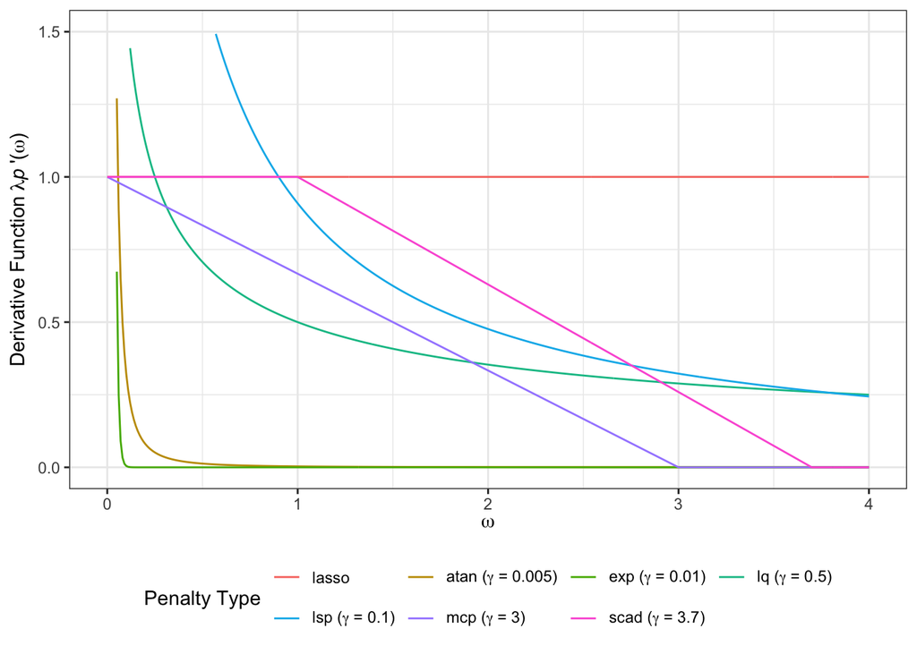

Figure 2: Illustrative penalty derivatives.

## Reference

Candès, Emmanuel J., Michael B. Wakin, and Stephen P. Boyd. 2008. “Enhancing Sparsity by Reweighted *ℓ*<sub>1</sub> Minimization.” *Journal of Fourier Analysis and Applications* 14 (5): 877–905. https://doi.org/10.1007/s00041-008-9045-x.

Fan, Jianqing, Yang Feng, and Yichao Wu. 2009. “Network Exploration via the Adaptive LASSO and SCAD Penalties.” *The Annals of Applied Statistics* 3 (2): 521–41. https://doi.org/10.1214/08-aoas215.

Fan, Jianqing, and Runze Li. 2001. “Variable Selection via Nonconcave Penalized Likelihood and Its Oracle Properties.” *Journal of the American Statistical Association* 96 (456): 1348–60. https://doi.org/10.1198/016214501753382273.

Frank, Lldiko E., and Jerome H. Friedman. 1993. “A Statistical View of Some Chemometrics Regression Tools.” *Technometrics* 35 (2): 109–35. https://doi.org/10.1080/00401706.1993.10485033.

Friedman, Jerome, Trevor Hastie, and Robert Tibshirani. 2008. “Sparse Inverse Covariance Estimation with the Graphical Lasso.” *Biostatistics* 9 (3): 432–41. https://doi.org/10.1093/biostatistics/kxm045.

Fu, Wenjiang J. 1998. “Penalized Regressions: The Bridge Versus the Lasso.” *Journal of Computational and Graphical Statistics* 7 (3): 397–416. https://doi.org/10.1080/10618600.1998.10474784.

Tibshirani, Robert. 1996. “Regression Shrinkage and Selection via the Lasso.” *Journal of the Royal Statistical Society: Series B (Methodological)* 58 (1): 267–88. https://doi.org/10.1111/j.2517-6161.1996.tb02080.x.

Wang, Yanxin, Qibin Fan, and Li Zhu. 2018. “Variable Selection and Estimation Using a Continuous Approximation to the *L*<sub>0</sub> Penalty.” *Annals of the Institute of Statistical Mathematics* 70 (1): 191–214. https://doi.org/10.1007/s10463-016-0588-3.

Wang, Yanxin, and Li Zhu. 2016. “Variable Selection and Parameter Estimation with the Atan Regularization Method.” *Journal of Probability and Statistics* 2016: 6495417. https://doi.org/10.1155/2016/6495417.

Zhang, Cun-Hui. 2010. “Nearly Unbiased Variable Selection Under Minimax Concave Penalty.” *The Annals of Statistics* 38 (2): 894–942. https://doi.org/10.1214/09-AOS729.

Zou, Hui. 2006. “The Adaptive Lasso and Its Oracle Properties.” *Journal of the American Statistical Association* 101 (476): 1418–29. https://doi.org/10.1198/016214506000000735.